# Test-time context construction for tabular foundation models under extreme class imbalance

Retrieval and class-ratio control in financial fraud detection

Theo Blauberg

September 2026

## Fraud detection is an extreme imbalance problem

- Fraudulent payment transactions in the EEA totalled 4.2 billion Euros in 2024, up 17 % from year before (European Banking Authority and European Central Bank 2025).
- Fraud rates by value sit between 0.001 % and 0.033 % in differen payment instruments.
  - The publicly available benchmark datasets used here are already heavily oversampled relative to production.
- Evaluation must concentrate on the minority class performance
  - Main evaluation metrics used in this thesis are PR-AUC and recall at fixed FPR.
  - Full dataset accuracy is meaningles at this scale of class imbalance.

## Wasting the context window

Naïve strategy would be to use a uniform random subsample. When the dataset is too large to fit in one pass.

- Number of expected fraud rows in a context size $B$ with prevalence $\pi$ is $\pi B$.
- EU credit-card data, $\pi = 0.0017$, $B = 10\text{ }000$ expacted number is about 17 fraud rows
- At production prevalences woudl be even worse

A randomly chosen context has two problems:

1. **Irrelevance** Most slots go to rows that say little about the transactions being scored.
2. **Class imbalance** The few fraud rows are too small a sample to characterise fraud from.

## Proposed method: Retrieval-Augmented Prediction (RAP)

[figure not shown]

## Two levers

- **relevance** kNN retrieval of similar training rows
- **class balance** fraud share raised by oversampling

Experimental conditions to test levers:

| ID | Context construction | Fraud ratio |
| --- | --- | --- |
| C1 | Random subsample | Natural |
| C2 | Stratified random subsample | Balanced (Sweep up to 50/50) |
| C3 | kNN retrieval per test cluster | Natural |
| C4 | kNN retrieval, full RAP | Enforced, swept 5 to 50 % |

## Research questions

- **RQ1.** How TFMs perform against GBDTs under random subsample?
- **RQ2.** Does controlling the fraud ratio help (C2 vs C1), and is there an optimal ratio?
- **RQ3.** Does a retrieved, relevant context help (C3 vs C1)?
- **RQ4.** Does combining the levers add anything (C4 vs other)?

## Experimental setup

**Models (tested frozen, no finetuning)**

- TabPFN v2/ 2.5 / 2.6 / v3 and TabICLv2
- Baselines: XGBoost, CatBoost with strong fixed defaults

**Datasets (fraud rate)**

- EU CC 285k rows (0.17 %)
- BankSim 595k (1.2 %), customer-grouped split
- PaySim 6.3M (0.13 %)
- FiFAR 603k (1.2 %), canonical split from literature
- BAF 1M (1.1 %)

Test ran with seeded stratified 80/20 splits. Evaluated on prevalence-corrected PR-AUC, recall at 1 % and 5 % FPR.

## RQ1: random-context TFMs vs full-data GBDTs

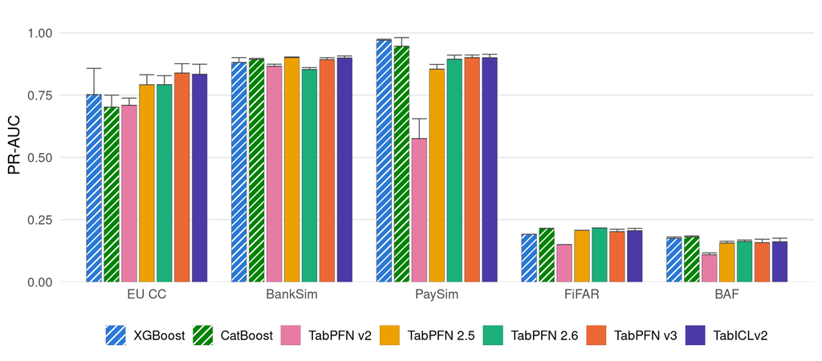

Figure 1

Roughly on par despite the asymmetry (GBDTs trained with the full training split, TFMs context window capped at 50k rows). Family means: GBDT 0.591, all TFMs 0.569, the two strongest TFMs 0.599. Best-in-family: 2 TFM wins, 1 tie, 2 losses.

## RQ2: ratio control works, everywhere

- Stratified balancing lifts **every model on every dataset**.
- The lift is largest where the window is smallest: +0.119 mean PR-AUC for TabPFN v2 (10k context)
  - +0.028 for TabPFN v3 and
  - +0.029 for TabICLv2.
- The gain in performance is measured on ranking metrics so it is genuine discrimination not just recalibration

## RQ2: the optimal ratio is a broad plateau

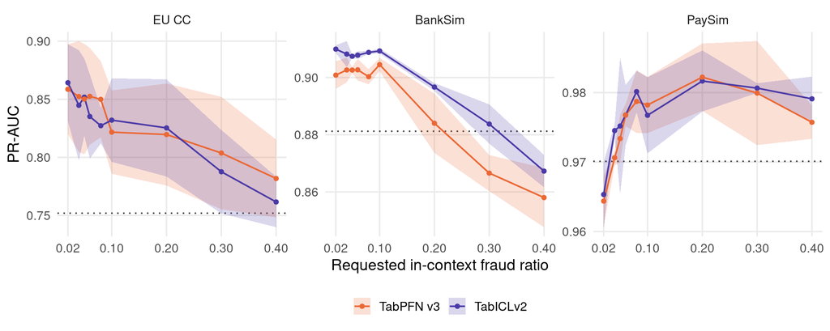

Figure 2

The runs have 50 000-row stratified context means over three seeds, bands one standard deviation. Dotted line is a full-data XGBoost. Ratios near 10 % sit close to the peak on every dataset. Past the point where unique fraud rows run out, higher ratios add duplicates and performance declines. For example, EU CC has only about 394 unique training frauds.

## RQ3: retrieval hurts

- Filling the context by kNN retrieval at the natural ratio scores **worse than the random context** on four of five datasets.
- Forcing finer groupings in the design-space sweep recovers part of the loss but asymptotes **below C2**.
- Ablation on different retrieval strategies
  - Swapping the **fraud** selector to kNN is nearly neutral.
  - Swapping the **legitimate** selector to kNN causes the collapse.

## RQ4: the full RAP still loses to balancing

Table 1

| Dataset | C1 | C2 | C3 | C4 (best ratio) | Best strategy |
| --- | --- | --- | --- | --- | --- |
| EU CC | 0.817 | **0.869** | 0.555 | 0.739 | C2 |
| BankSim | 0.907 | **0.909** | 0.859 | 0.673 | C2 ≈ C1 |
| PaySim | 0.909 | **0.983** | 0.128 | 0.563 | C2 |
| FiFAR | 0.217 | **0.222** | 0.199 | 0.053 | C2 |
| BAF | 0.163 | **0.183** | 0.168 | 0.016 | C2 |

## Best case vs published state of the art: EU CC

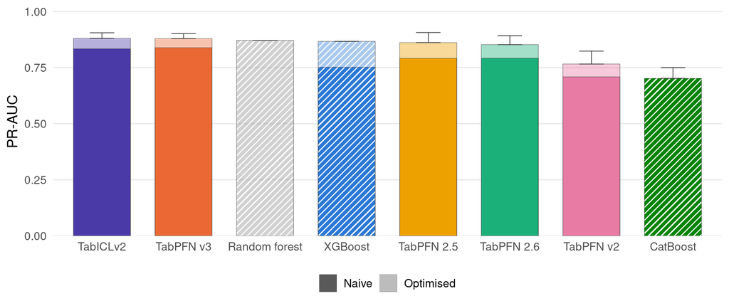

Figure 3

## Future work

- More complex retrieval strategies.
- SMOTE-style minority synthesis instead of with-replacement duplication on fraud-scarce data.
- Same-protocol head-to-head against post-hoc threshold correction.
- Does the verdict hold on real transaction streams?
  - Larger datasets and more heterogenous examples force other context building schemes.

Thank you. Questions?

## References

Andrade-Arenas, Laberiano, and Cesar Yactayo-Arias. 2025. “Comparative Analysis of Machine Learning Models for Credit Card Fraud Detection Using SMOTE for Class Imbalance.” *International Journal of Safety and Security Engineering* 15 (5): 893–901. https://doi.org/10.18280/ijsse.150504.

European Banking Authority, and European Central Bank. 2025. *2025 Report on Payment Fraud*. EBA/REP/2025/40. European Banking Authority; European Central Bank. https://www.eba.europa.eu/sites/default/files/2025-12/1709846a-84d9-47cf-86a0-b155efb34d66/EBA%20and%20ECB%20Report%20on%20Payment%20Fraud.pdf.